# 디지털 글쓰기 수업

Author

waterfirst

## 1 Introduction

이 수업은 코딩을 전혀 모르는 사람들을 대상으로 디지털글쓰기 수업을 위해 만들었습니다.

자신만의 포트폴리오, 레포트, 웹페이지를 만드는 마크다운 방식의 글쓰기를 먼저 배울것입니다.

그리고 그 내용물을 채울 때 필요한 R 언어에 대한 기초를 배우고, 텍스트 분석까지 해보는 것을 목표로 하고 있습니다.

R 언어 간단 소개

두명의 뉴질랜드 통계학자가 만듦 : 로버트 젠틀맨(Robert Gentleman)과 로스 이하카(Ross Ihaka)

해들리 위컴에 의해 빅데이터 툴로 발전함 (대표적 : ggplot, tidyverse)

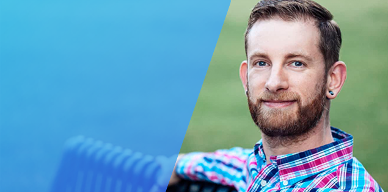

줄리아실기 : 문자분석(tidytext), 머신러닝(tidymodel)

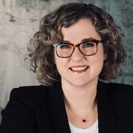

언어의 특징 : 1부터 시작 (다른 언어들은 0부터 시작)

- 패키지 설치 / 불러오기 : install.packages(“패키지이름”) / library(패키지이름)

### 프로그램 구분

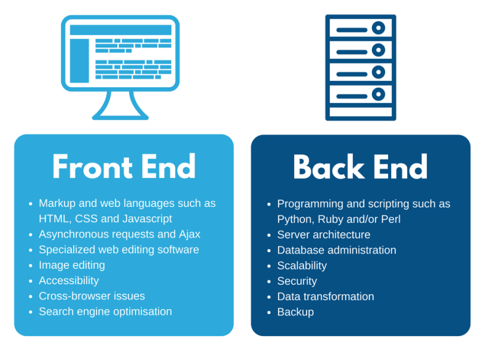

이 많은 것을 다 배워야 할까? 어렵다.

R에서 프론트엔드를 하려면 어떻게 할까? 즉 눈에 보이는 문서, 웹페이지를 만들려면?

**Quarto**는 **RMarkdown** 기반 **디지털 글쓰기** 양식이다.

R도 모르는데 Quarto는 또 무엇인가?

잘 모르지만 이 강의를 듣게 되면 무엇을 할 수 있는지를 보자.

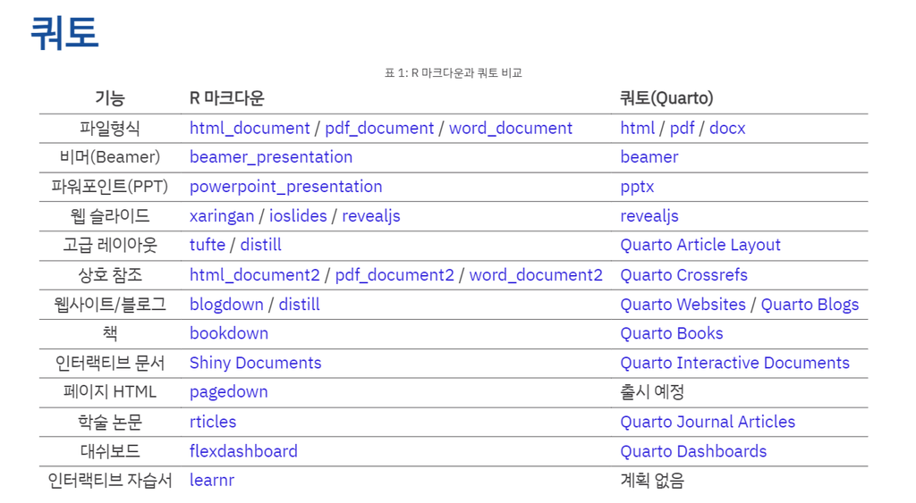

https://quarto.org/docs/gallery/

https://r2bit.com/bitSlide/dashboard_202404.html#/%EC%BF%BC%ED%86%A0-1

### **강의 순서**

1. Markdown 문법 배우기 (1주차)

   https://quarto.org/docs/authoring/markdown-basics.html
2. Documents 를 좀 더 확장해서 배우기 (2주차)

   https://quarto.org/docs/presentations/revealjs/
3. Dashboard 만들기 (3주차)

   https://blog.zarathu.com/posts/2023-12-11-quarto-dashboard/
4. 텍스트 분석 (4주차)
   - 문자열 정제 (stringr)
   - 관계도 분석 (tidygraph, ggraph)

참고사이트

[문자열함수 : stringr]https://bookdown.org/sulgi/r4ds/strings.html

[한국문자분석 : bitNLP]https://github.com/bit2r/bitNLP

[문자분석 : tidytext]https://github.com/juliasilge/tidytext

[관계망 분석 : tidygraph]https://github.com/thomasp85/tidygraph

[관계망 분석 : ggraph] https://github.com/thomasp85/ggraph

[Quarto 문서화 : quarto]https://quarto.org/docs/presentations/revealjs/

### 프로그램 설치

(#1~5까지 하고, #6,7은 나중에~~)

1. R 설치 : https://posit.co/download/rstudio-desktop/
2. RStudio 설치 https://posit.co/download/rstudio-desktop/
3. Quarto CLI설치 : https://quarto.org/docs/download/
4. Latex 설치 : (Rstudio 터미널창) **$ quarto install tinytex**
5. 출판용 사이트 가입 : https://quartopub.com/
6. github 가입 : https://github.com/
7. git 설치 : https://git-scm.com/download/win

[Quarto ]https://quarto.org/docs/presentations/revealjs/

프로그램을 배울 때, 다운로드, 설치, 환경설정만 하면 50%는 이미 배운것입니다. ^^

### RStudio 설명

[figure not shown]

```r
print("Hello World!!")
```

```
[1] "Hello World!!"
```

R은 통계 전문 프로그래 언어이지만 코딩 언어는 나중에 배우고 우리는 문서 작성 Tool 로서 Quarto라는 새로운 세계를 먼저 배울 것입니다.

우선 패키지 하나만 설치하고 갑시다. (tidyverse : 패키지 선물세트)

```r
#install.packages("tidyverse)
library(tidyverse)
```

## 2 Markdown 문법 배우기

[참고문헌 1] 한국 R 사용자 협회 문서  
https://r2bit.com/gpt-quarto/part_markdown.html

[참고문헌 2] Quarto 사이트 https://quarto.org/docs/authoring/markdown-basics.html

[참고문헌 3] R https://rchemistblog.com/blog/posts/2023-01-19-quarto-intro/

따라해보기~~ (50분)

각자 주제를 하나 정한 후 그 내용으로 문서를 작성해봅니다. 문서 내용은 AI에게 물어서 작성해봅니다.

1. Bing chat : https://www.bing.com/chat?form=CONVRD
2. Openai : https://chatgpt.com/
3. 클로드3 : https://claude.ai/
4. 클로버 X : https://clova-x.naver.com/welcome

특별히 AI에게 “마크다운 문서로 작성해줘” 라고 하면 마크다운 문법으로 글, 표를 작성해줍니다.

이미지는 “images” 폴더를 하나 만들어서 그 안에 저장해줍니다.

### 자신의 웹사이트에 문서 올리기

- File -> New Project -> New Directory -> Quarto Website -> Directory 이름 적기
- “index.qmd” 로 저장하기
- 문서가 다 작성되었으면 윗쪽 **Render** 누르면 html 파일이 만들어짐.
- 폴더창에 “images” 를 만든 후 이미지 저장
- about.qmd 파일 안에 이미지 넣기
- 콘솔창의 터미널로 가기
- $ quarto publish quarto-pub
- Authorize (Y/n) -> 엔터, 엔터

## Day2

### 복습

- Render 후 Viewer 창에서 결과물을 보려면

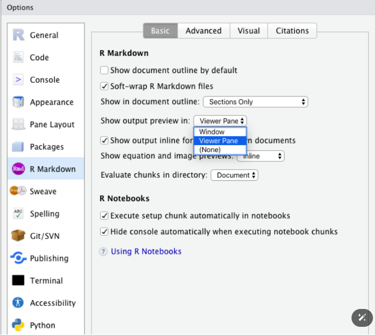

- 지난번 작성한 프로젝트를 열어봅시다. (QuartoPub에 웹페이지로 올린 프로젝트)
- 또하나의 qmd 파일을 추가해봅시다.

  _quarto.yml 파일을 보자. about 윗쪽에 새로운 qmd 파일을 넣자

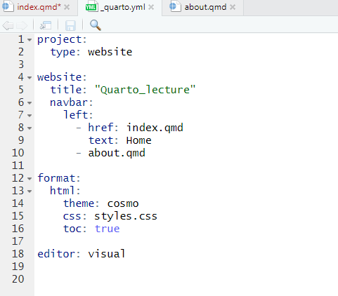

- Render -> html 파일 확인 -> QuartoPub에 게시 (Terminal 창 : quarto publish quarto-pub)

## 1. YAML 헤더에 꾸미기 넣기

### 제목을 이미지로 넣기

```
---
title-block-banner: images/banner.jpeg
---
```

### 목차 위치 바꾸기

```
---
format:
  html:
    toc: true
    toc-location: left
---
```

### 목차 아래에 참고할만한 사이트 추가하자

```
---
format:
  html:
    other-links:
      - text: NASA Open Data
        href: https://data.nasa.gov/
---
```

### 링크 앞에 아이콘을 넣어보자

https://icons.getbootstrap.com/

```
---
format:
  html:
    other-links:
      - text: NASA Open Data
        href: https://data.nasa.gov/
    code-links:
      - text: Data Import Code
        icon: file-code
        href: data-import.py
---
```

### 외부 링크 옆에 아이콘을 붙이고, 새로운 창으로 열려면 : YAML 헤더에 추가

```
format:
  html:
    link-external-icon: true
    link-external-newwindow: true
    link-external-filter: '^(?:http:|https:)\/\/www\.quarto\.org\/custom'
```

### 이미지를 클릭하면 줌인 되도록 하려면 : YAML 헤더에 추가

```
lightbox: true
```

## 2. 문서안에서 꾸미기

### 탭 세트

```
::: {.panel-tabset}
#### 대한민국
```

수도 : 서울

```
#### 중국
```

수도 : 베이징

```
#### 일본
```

수도 : 도쿄

**대한민국**

```
수도 : 서울
```

**중국**

```
수도 : 베이징
```

**일본**

```
수도 : 도쿄
```

### 색깔있는 박스 넣기

[참고]https://quarto.org/docs/authoring/callouts.html

- note
- warning
- important
- tip
- caution

```
::: {.callout-note}
하늘색 : 간단한 코멘트 넣기 (강조할 때는 단어 앞뒤고 `로 감싸기)
Note that there are five types of callouts, including:
`note`, `warning`, `important`, `tip`, and `caution`.
:::

::: {.callout-tip}
## Tip with Title
연두색 : 팁 (팁에 제목 넣기)
This is an example of a callout with a title.
:::

::: {.callout-warning}
## Warning with Title
노란색 : 주의
This is an example of a callout with a title.
:::


::: {.callout-important}
## Important with Title
분홍색 : 중요
This is an example of a callout with a title.
:::


::: {.callout-caution collapse="true"}
## Expand To Learn About Collapse
주황색 : 펼쳐보이기 (팁에 제목 넣기)

This is an example of a 'folded' caution callout that can be expanded by the user. You can use `collapse="true"` to collapse it by default or `collapse="false"` to make a collapsible callout that is expanded by default.
:::
```

**Note**

하늘색 : 간단한 코멘트 넣기 (강조할 때는 단어 앞뒤고 `로 감싸기) Note that there are five types of callouts, including:`note`,`warning`,`important`,`tip`, and`caution`.

**Tip with Title**

연두색 : 팁 (팁에 제목 넣기) This is an example of a callout with a title.

**Warning with Title**

노란색 : 주의 This is an example of a callout with a title.

**Important with Title**

분홍색 : 중요 This is an example of a callout with a title.

**Expand To Learn About Collapse**

주황색 : 펼쳐보이기 (팁에 제목 넣기)

This is an example of a ‘folded’ caution callout that can be expanded by the user. You can use `collapse="true"` to collapse it by default or `collapse="false"` to make a collapsible callout that is expanded by default.

tip box를 언급할 때는 *@tip-“이름”* 으로 부를 수 있다.

**Tip 1: Cross-Referencing a Tip**

Add an ID starting with `#tip-` to reference a tip.

See Tip 1…

## 3. pdf 문서 만들기(YAML format 바꾸기)

https://quarto.org/docs/output-formats/pdf-basics.html

```
---
title: "My document"
format:
  pdf:
    toc: true
    number-sections: true
    colorlinks: true
---
```

## 4. typst 문서(pdf와 비슷) 만들기(YAML format 바꾸기)

https://quarto.org/docs/output-formats/typst.html

```
---
title: "Hello Typst!"
format:
  typst:
    toc: true
    section-numbering: 1.1.a
    columns: 2
---
```

## 5. Word 문서 만들기(YAML format 바꾸기)

https://quarto.org/docs/output-formats/ms-word.html

```
---
title: "My Document"
format:
  docx:
    toc: true
    number-sections: true
    highlight-style: github
---
```

## 6. 웹슬라이드 문서 만들기 (발표형식)

https://r2bit.com/gpt-quarto/dw_slideshow.html

```
---
title: "Habits"
author: "John Doe"
format: revealjs
---

## 제목1

- 내용1
- 내용2

## 제목2

- 내용1
- 내용2
```

- 각자 주제를 정해서 웹슬라이드를 만들고 QuartoPub에 게시해보자 (50분)

## 7. github에 게시하기

- github 가입하기

  new repository 만들기 page -> main -> save
- git download https://git-scm.com/

설치 완료 후 Git bash 열고 환경 설정

https://hackmd.io/@oW_dDxdsRoSpl0M64Tfg2g/ByfwpNJ-K

- github에 올리기 https://minitistics.tistory.com/27

File - New Project - Versioin Control - github 레포지토리 주소 넣기

- 환경창에 Git -> commit -> Push

<끝>